# Tugas Pertemuan 2

Zanira Husna G1401231097

# Persiapan Data

## Library/Packages

```r
library("forecast")
```

```r
library("graphics")
library("TTR")
library("TSA")
library("ggplot2")
```

## Impor Data

```r
library(readxl)
data <- read_xlsx("C:\\Users\\ZANIRA\\Downloads\\laporan_iklim_harian-250831182901.xlsx", skip = 258, n_max = 125)

# Ganti nama kolom 1 sampai 4
colnames(data)[1:4] <- c("TANGGAL", "TAVG", "RR", "FF_AVG")
data$TANGGAL <- as.Date(data$TANGGAL, format = "%d-%m-%Y")

# ambil kolom yang ingin diuji saja
subset_data <- data[, c("TANGGAL", "TAVG")]

head(subset_data)
```

```
## # A tibble: 6 × 2
##   TANGGAL     TAVG
##   <date>     <dbl>
## 1 2024-11-25  27.2
## 2 2024-11-26  27.5
## 3 2024-11-27  25.3
## 4 2024-11-28  26.2
## 5 2024-11-29  26.9
## 6 2024-11-30  27.6
```

## Eksplorasi Data

```r
View(subset_data)
str(subset_data)
```

```
## tibble [125 × 2] (S3: tbl_df/tbl/data.frame)
##  $ TANGGAL: Date[1:125], format: "2024-11-25" "2024-11-26" ...
##  $ TAVG   : num [1:125] 27.2 27.5 25.3 26.2 26.9 27.6 28.1 26.4 26 25 ...
```

```r
dim(subset_data)
```

```
## [1] 125   2
```

```r
# cek data kosong
colSums(is.na(subset_data))
```

```
## TANGGAL    TAVG
##       0       0
```

```r
# 8888: Data tidak terukur, 9999: Tidak Ada Data (tidak dilakukan pengukuran)
subset(subset_data, TAVG == 8888 | TAVG == 9999 | TAVG == "-")
```

```
## # A tibble: 0 × 2
## # ℹ 2 variables: TANGGAL <date>, TAVG <dbl>
```

Mengubah data agar terbaca sebagai data deret waktu dengan fungsi `ts()` .

```r
data.ts <- ts(subset_data$TAVG)
data.ts
```

```
## Time Series:
## Start = 1
## End = 125
## Frequency = 1
##   [1] 27.2 27.5 25.3 26.2 26.9 27.6 28.1 26.4 26.0 25.0 25.1 25.5 26.9 27.0 24.8
##  [16] 25.5 27.1 27.4 28.0 25.7 25.8 24.8 26.8 25.5 24.9 25.2 26.4 25.6 25.7 25.5
##  [31] 25.8 26.6 26.4 27.4 27.5 25.8 27.1 26.3 27.1 27.0 26.7 27.2 26.6 26.4 27.0
##  [46] 25.5 26.7 26.2 26.6 26.3 25.0 26.7 25.8 26.3 25.9 25.6 25.4 25.5 25.6 25.4
##  [61] 24.4 25.7 26.1 26.1 23.7 25.3 25.4 26.4 26.3 26.7 26.8 25.7 26.9 26.1 26.5
##  [76] 25.1 26.2 26.8 27.2 26.9 27.4 26.8 26.2 26.2 25.0 25.9 26.1 25.3 26.5 25.9
##  [91] 25.3 25.4 25.9 25.4 25.5 25.8 26.3 26.3 26.3 25.6 26.9 26.1 26.5 26.2 25.9
## [106] 24.6 26.6 27.1 26.9 25.7 25.2 26.5 25.0 26.2 26.3 27.1 27.4 26.9 26.9 26.1
## [121] 25.6 25.5 25.4 26.2 26.2
```

Menampilkan ringkasan data

```r
summary(data.ts)
```

```
##    Min. 1st Qu.  Median    Mean 3rd Qu.    Max.
##   23.70   25.50   26.20   26.15   26.80   28.10
```

Membuat plot data deret waktu

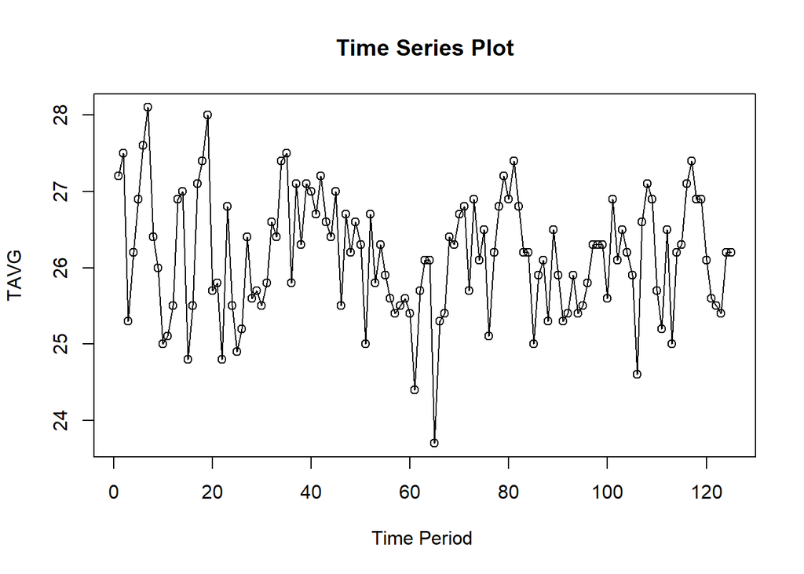

```r
ts.plot(data.ts, xlab="Time Period ", ylab="TAVG",
        main = "Time Series Plot")
points(data.ts)
```

## Pembagian Data

Pembagian data latih dan data uji dilakukan dengan perbandingan 80% data latih dan 20% data uji.

```r
# hitung jumlah data
n <- nrow(subset_data)

# tentukan batas 80%
n_train <- floor(0.8 * n)

# bagi data
training <- subset_data[1:n_train, ]
testing  <- subset_data[(n_train+1):n, ]

# ubah ke time series
train.ts <- ts(training$TAVG)
test.ts  <- ts(testing$TAVG)
```

Eksplorasi data dilakukan pada keseluruhan data, data latih serta data uji menggunakan plot data deret waktu.

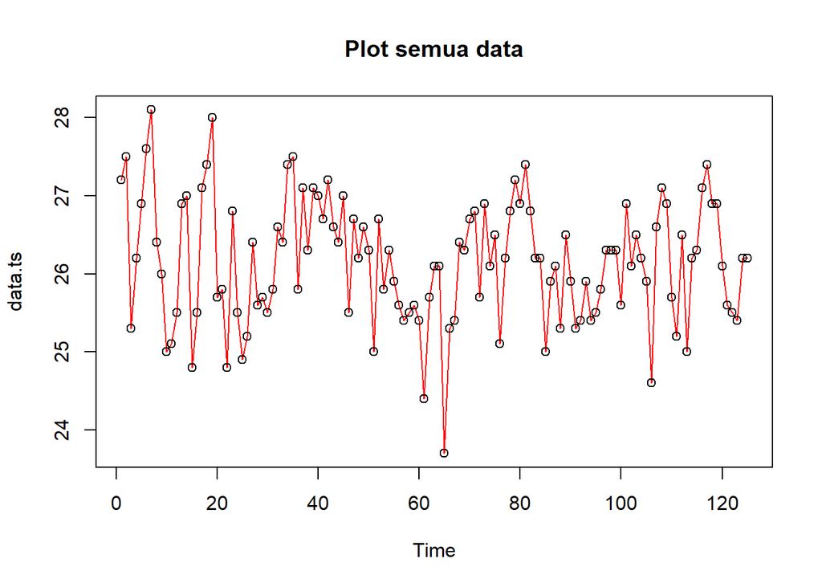

```r
#eksplorasi keseluruhan data
plot(data.ts, col="red",main="Plot semua data")
points(data.ts)
```

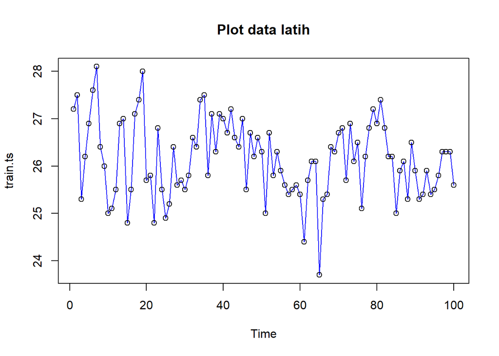

```r
#eksplorasi data latih
plot(train.ts, col="blue",main="Plot data latih")
points(train.ts)
```

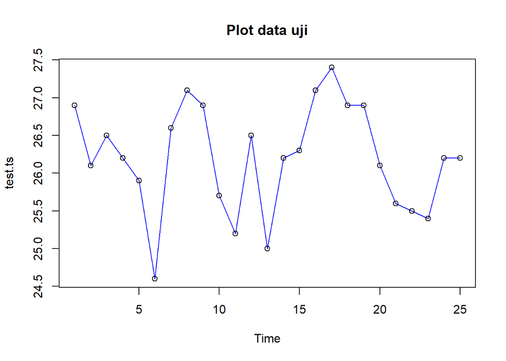

```r
#eksplorasi data uji
plot(test.ts, col="blue",main="Plot data uji")
points(test.ts)
```

# Forecast tiap model

## Single Moving Average (SMA)

```r
data.sma<-SMA(train.ts, n=4)
data.sma
```

```
## Time Series:
## Start = 1
## End = 100
## Frequency = 1
##   [1]     NA     NA     NA 26.550 26.475 26.500 27.200 27.250 27.025 26.375
##  [11] 25.625 25.400 25.625 26.125 26.050 26.050 26.100 26.200 27.000 27.050
##  [21] 26.725 26.075 25.775 25.725 25.500 25.600 25.500 25.525 25.725 25.800
##  [31] 25.650 25.900 26.075 26.550 26.975 26.775 26.950 26.675 26.575 26.875
##  [41] 26.775 27.000 26.875 26.725 26.800 26.375 26.400 26.350 26.250 26.450
##  [51] 26.025 26.150 25.950 25.950 26.175 25.900 25.800 25.600 25.525 25.475
##  [61] 25.225 25.275 25.400 25.575 25.400 25.300 25.125 25.200 25.850 26.200
##  [71] 26.550 26.375 26.525 26.375 26.300 26.150 25.975 26.150 26.325 26.775
##  [81] 27.075 27.075 26.825 26.650 26.050 25.825 25.800 25.575 25.950 25.950
##  [91] 25.750 25.775 25.625 25.500 25.550 25.650 25.750 25.975 26.175 26.125
```

```r
data.ramal<-c(NA,data.sma)
data.ramal #forecast 1 periode ke depan
```

```
##   [1]     NA     NA     NA     NA 26.550 26.475 26.500 27.200 27.250 27.025
##  [11] 26.375 25.625 25.400 25.625 26.125 26.050 26.050 26.100 26.200 27.000
##  [21] 27.050 26.725 26.075 25.775 25.725 25.500 25.600 25.500 25.525 25.725
##  [31] 25.800 25.650 25.900 26.075 26.550 26.975 26.775 26.950 26.675 26.575
##  [41] 26.875 26.775 27.000 26.875 26.725 26.800 26.375 26.400 26.350 26.250
##  [51] 26.450 26.025 26.150 25.950 25.950 26.175 25.900 25.800 25.600 25.525
##  [61] 25.475 25.225 25.275 25.400 25.575 25.400 25.300 25.125 25.200 25.850
##  [71] 26.200 26.550 26.375 26.525 26.375 26.300 26.150 25.975 26.150 26.325
##  [81] 26.775 27.075 27.075 26.825 26.650 26.050 25.825 25.800 25.575 25.950
##  [91] 25.950 25.750 25.775 25.625 25.500 25.550 25.650 25.750 25.975 26.175
## [101] 26.125
```

dilakukan peramalan sebanyak 25 periode sesuai dengan jumlah data uji.

```r
data.gab<-cbind(
  aktual=c(data.ts),
  pemulusan=c(data.sma,rep(NA,25)),
  ramalan=c(data.ramal,rep(data.ramal[length(data.ramal)],24)))

head(data.gab, 10)
```

```
##       aktual pemulusan ramalan
##  [1,]   27.2        NA      NA
##  [2,]   27.5        NA      NA
##  [3,]   25.3        NA      NA
##  [4,]   26.2    26.550      NA
##  [5,]   26.9    26.475  26.550
##  [6,]   27.6    26.500  26.475
##  [7,]   28.1    27.200  26.500
##  [8,]   26.4    27.250  27.200
##  [9,]   26.0    27.025  27.250
## [10,]   25.0    26.375  27.025
```

Adapun plot data deret waktu dari hasil peramalan yang dilakukan adalah sebagai berikut.

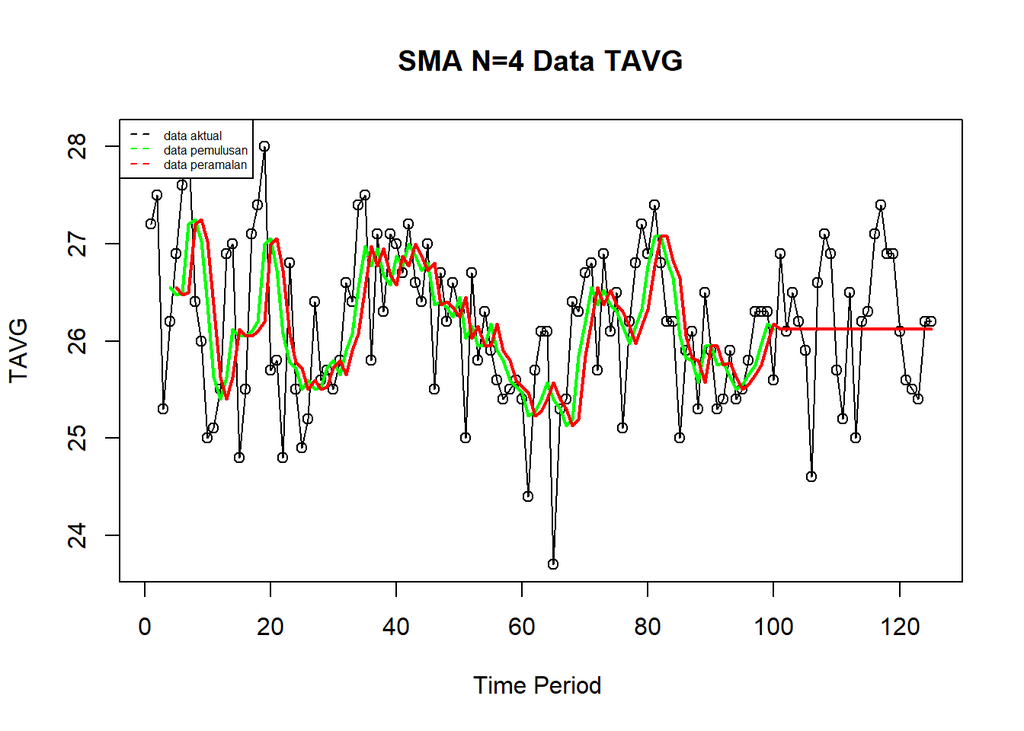

```r
ts.plot(data.ts, xlab="Time Period ", ylab="TAVG", main= "SMA N=4 Data TAVG")
points(data.ts)
lines(data.gab[,2],col="green",lwd=2)
lines(data.gab[,3],col="red",lwd=2)
legend("topleft",c("data aktual","data pemulusan","data peramalan"), lty=8, col=c("black","green","red"), cex=0.5)
```

```r
#Menghitung nilai keakuratan data latih
error_train.sma = train.ts-data.ramal[1:length(train.ts)]

SSE_train.sma = sum(error_train.sma[5:length(train.ts)]^2)
MSE_train.sma = mean(error_train.sma[5:length(train.ts)]^2)
MAPE_train.sma = mean(abs((error_train.sma[5:length(train.ts)]/train.ts[5:length(train.ts)])*100))

akurasi_train.sma <- matrix(c(SSE_train.sma, MSE_train.sma, MAPE_train.sma))
row.names(akurasi_train.sma)<- c("SSE", "MSE", "MAPE")
colnames(akurasi_train.sma) <- c("Akurasi m = 4")
akurasi_train.sma
```

```
##      Akurasi m = 4
## SSE     67.4731250
## MSE      0.7028451
## MAPE     2.5790386
```

Dalam hal ini nilai MAPE data latih pada metode pemulusan SMA sekitar 2,5%. Selanjutnya dilakukan perhitungan nilai MAPE data uji pada metode pemulusan SMA.

```r
#Menghitung nilai keakuratan data uji
error_test.sma = test.ts-data.gab[101:125,3]

SSE_test.sma = sum(error_test.sma^2)
MSE_test.sma = mean(error_test.sma^2)
MAPE_test.sma = mean(abs((error_test.sma/test.ts*100)))

akurasi_test.sma <- matrix(c(SSE_test.sma, MSE_test.sma, MAPE_test.sma))
row.names(akurasi_test.sma)<- c("SSE", "MSE", "MAPE")
colnames(akurasi_test.sma) <- c("Akurasi m = 4")
akurasi_test.sma
```

```
##      Akurasi m = 4
## SSE      12.360625
## MSE       0.494425
## MAPE      2.169571
```

Perhitungan akurasi menggunakan data latih menghasilkan nilai MAPE yang kurang dari 10% sehingga nilai akurasi ini dapat dikategorikan sebagai sangat baik.

## Double Moving Average (DMA)

```r
dma <- SMA(data.sma, n = 4)
At <- 2*data.sma - dma
Bt <- 2/(4-1)*(data.sma - dma)
data.dma<- At+Bt
data.ramal2<- c(NA, data.dma)

t = 1:25
f = c()

for (i in t) {
  f[i] = At[length(At)] + Bt[length(Bt)]*(i)
}

data.gab2 <- cbind(aktual = c(data.ts),
                   pemulusan1 = c(data.sma,rep(NA,25)),
                   pemulusan2 = c(dma, rep(NA,25)),
                   At = c(At, rep(NA,25)),
                   Bt = c(Bt,rep(NA,25)),
                   ramalan = c(data.ramal2, f[-1]))

head(data.gab2, 10)
```

```
##       aktual pemulusan1 pemulusan2       At          Bt  ramalan
##  [1,]   27.2         NA         NA       NA          NA       NA
##  [2,]   27.5         NA         NA       NA          NA       NA
##  [3,]   25.3         NA         NA       NA          NA       NA
##  [4,]   26.2     26.550         NA       NA          NA       NA
##  [5,]   26.9     26.475         NA       NA          NA       NA
##  [6,]   27.6     26.500         NA       NA          NA       NA
##  [7,]   28.1     27.200   26.68125 27.71875  0.34583333       NA
##  [8,]   26.4     27.250   26.85625 27.64375  0.26250000 28.06458
##  [9,]   26.0     27.025   26.99375 27.05625  0.02083333 27.90625
## [10,]   25.0     26.375   26.96250 25.78750 -0.39166667 27.07708
```

Hasil pemulusan menggunakan metode DMA divisualisasikan sebagai berikut

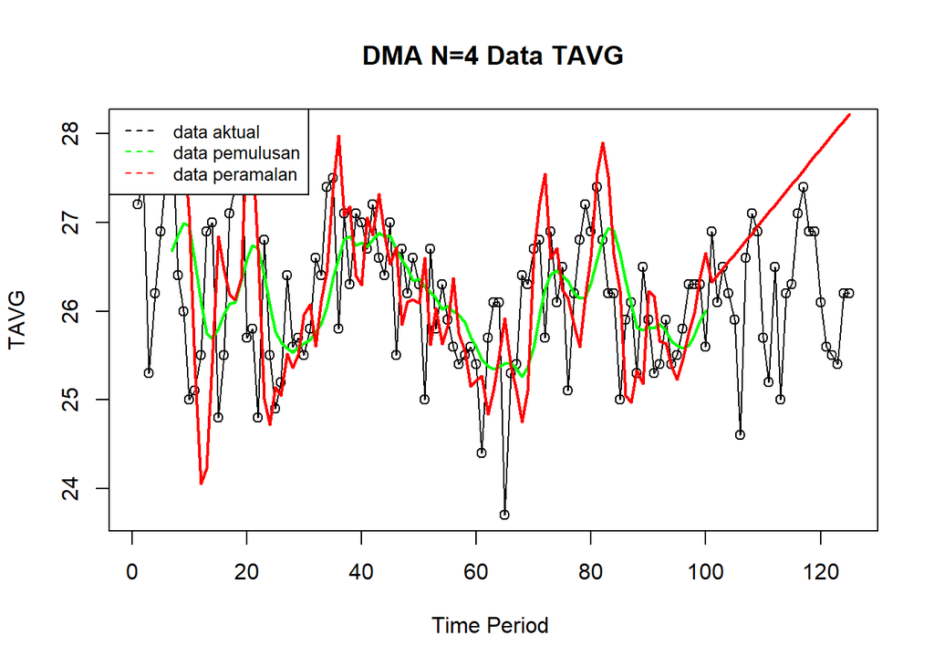

```r
ts.plot(data.ts, xlab="Time Period ", ylab="TAVG", main= "DMA N=4 Data TAVG")
points(data.ts)
lines(data.gab2[,3],col="green",lwd=2)
lines(data.gab2[,6],col="red",lwd=2)
legend("topleft",c("data aktual","data pemulusan","data peramalan"), lty=8, col=c("black","green","red"), cex=0.8)
```

Selanjutnya perhitungan akurasi dilakukan baik pada data latih maupun data uji. Perhitungan akurasi dilakukan dengan ukuran akurasi SSE, MSE dan MAPE.

```r
#Menghitung nilai keakuratan data latih
error_train.dma = train.ts-data.ramal2[1:length(train.ts)]

SSE_train.dma = sum(error_train.dma[8:length(train.ts)]^2)
MSE_train.dma = mean(error_train.dma[8:length(train.ts)]^2)
MAPE_train.dma = mean(abs((error_train.dma[8:length(train.ts)]/train.ts[8:length(train.ts)])*100))

akurasi_train.dma <- matrix(c(SSE_train.dma, MSE_train.dma, MAPE_train.dma))
row.names(akurasi_train.dma)<- c("SSE", "MSE", "MAPE")
colnames(akurasi_train.dma) <- c("Akurasi m = 4")
akurasi_train.dma
```

```
##      Akurasi m = 4
## SSE      99.697374
## MSE       1.072015
## MAPE      3.115730
```

Perhitungan akurasi pada data latih menggunakan nilai MAPE menghasilkan nilai MAPE yang kurang dari 10% sehingga dikategorikan sangat baik. Selanjutnya, perhitungan nilai akurasi dilakukan pada data uji.

```r
#Menghitung nilai keakuratan data uji
error_test.dma = test.ts-data.gab2[101:125,6]
SSE_test.dma = sum(error_test.dma^2)
MSE_test.dma = mean(error_test.dma^2)
MAPE_test.dma = mean(abs((error_test.dma/test.ts*100)))

akurasi_test.dma <- matrix(c(SSE_test.dma, MSE_test.dma, MAPE_test.dma))
row.names(akurasi_test.dma)<- c("SSE", "MSE", "MAPE")
colnames(akurasi_test.dma) <- c("Akurasi m = 4")
akurasi_test.dma
```

```
##      Akurasi m = 4
## SSE      50.349657
## MSE       2.013986
## MAPE      4.416579
```

Pada data latih maupun uji, metode SMA lebih baik dibandingkan dengan metode DMA.

## Single Exponential Smoothing

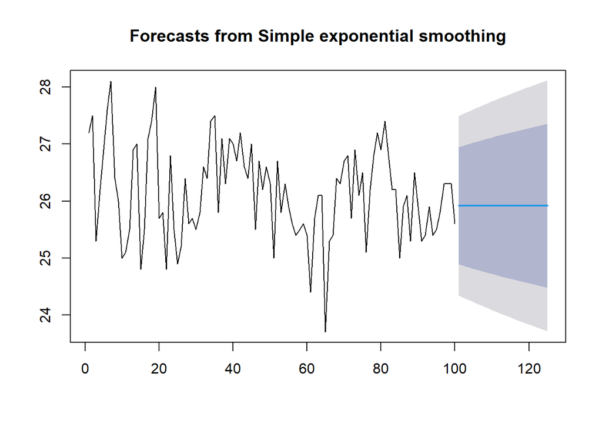

```r
#Cara 1 (fungsi ses)
ses.1 <- ses(train.ts, h = 25, alpha = 0.2)
plot(ses.1)
```

```r
ses.1
```

```
##     Point Forecast    Lo 80    Hi 80    Lo 95    Hi 95
## 101       25.91807 24.89183 26.94432 24.34856 27.48758
## 102       25.91807 24.87150 26.96464 24.31748 27.51866
## 103       25.91807 24.85157 26.98458 24.28699 27.54915
## 104       25.91807 24.83199 27.00415 24.25706 27.57908
## 105       25.91807 24.81277 27.02337 24.22766 27.60848
## 106       25.91807 24.79388 27.04227 24.19876 27.63738
## 107       25.91807 24.77529 27.06085 24.17034 27.66580
## 108       25.91807 24.75701 27.07914 24.14238 27.69377
## 109       25.91807 24.73900 27.09714 24.11484 27.72130
## 110       25.91807 24.72127 27.11487 24.08773 27.74842
## 111       25.91807 24.70380 27.13234 24.06100 27.77514
## 112       25.91807 24.68658 27.14957 24.03466 27.80148
## 113       25.91807 24.66959 27.16655 24.00868 27.82746
## 114       25.91807 24.65283 27.18331 23.98305 27.85309
## 115       25.91807 24.63629 27.19985 23.95776 27.87839
## 116       25.91807 24.61996 27.21618 23.93278 27.90336
## 117       25.91807 24.60384 27.23231 23.90812 27.92802
## 118       25.91807 24.58790 27.24824 23.88376 27.95239
## 119       25.91807 24.57216 27.26398 23.85968 27.97646
## 120       25.91807 24.55660 27.27954 23.83588 28.00026
## 121       25.91807 24.54122 27.29493 23.81236 28.02379
## 122       25.91807 24.52600 27.31014 23.78909 28.04706
## 123       25.91807 24.51095 27.32519 23.76607 28.07007
## 124       25.91807 24.49606 27.34008 23.74330 28.09285
## 125       25.91807 24.48133 27.35482 23.72076 28.11538
```

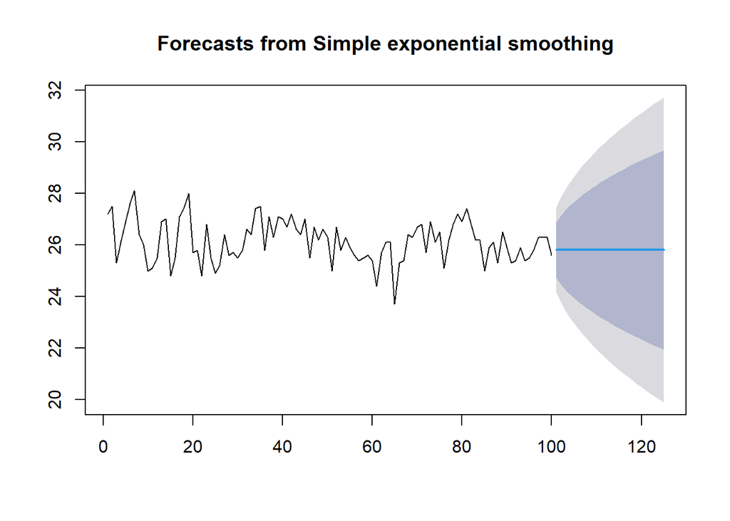

```r
ses.2<- ses(train.ts, h = 25, alpha = 0.7)
plot(ses.2)
```

```r
ses.2
```

```
##     Point Forecast    Lo 80    Hi 80    Lo 95    Hi 95
## 101       25.80523 24.72438 26.88608 24.15221 27.45824
## 102       25.80523 24.48588 27.12457 23.78746 27.82299
## 103       25.80523 24.28434 27.32612 23.47922 28.13123
## 104       25.80523 24.10654 27.50392 23.20731 28.40315
## 105       25.80523 23.94566 27.66479 22.96127 28.64919
## 106       25.80523 23.79764 27.81282 22.73488 28.87557
## 107       25.80523 23.65980 27.95065 22.52408 29.08637
## 108       25.80523 23.53030 28.08015 22.32603 29.28443
## 109       25.80523 23.40778 28.20267 22.13866 29.47180
## 110       25.80523 23.29123 28.31922 21.96041 29.65005
## 111       25.80523 23.17985 28.43060 21.79006 29.82039
## 112       25.80523 23.07300 28.53745 21.62665 29.98380
## 113       25.80523 22.97018 28.64027 21.46940 30.14105
## 114       25.80523 22.87096 28.73949 21.31766 30.29280
## 115       25.80523 22.77499 28.83547 21.17088 30.43958
## 116       25.80523 22.68196 28.92849 21.02861 30.58185
## 117       25.80523 22.59163 29.01883 20.89045 30.72000
## 118       25.80523 22.50376 29.10669 20.75608 30.85438
## 119       25.80523 22.41818 29.19227 20.62518 30.98527
## 120       25.80523 22.33470 29.27575 20.49752 31.11293
## 121       25.80523 22.25319 29.35726 20.37286 31.23760
## 122       25.80523 22.17351 29.43695 20.25099 31.35947
## 123       25.80523 22.09553 29.51492 20.13174 31.47872
## 124       25.80523 22.01916 29.59129 20.01494 31.59551
## 125       25.80523 21.94431 29.66615 19.90046 31.71000
```

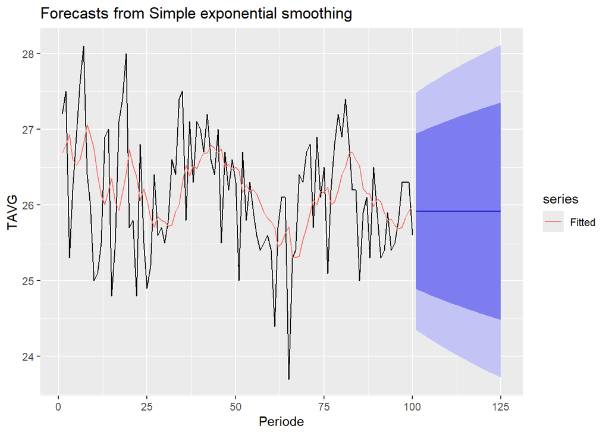

```r
autoplot(ses.1) +
  autolayer(fitted(ses.1), series="Fitted") +
  ylab("TAVG") + xlab("Periode")
```

Selanjutnya akan digunakan fungsi `HoltWinters()` dengan nilai inisialisasi parameter dan panjang periode peramalan yang sama dengan fungsi `ses()` .

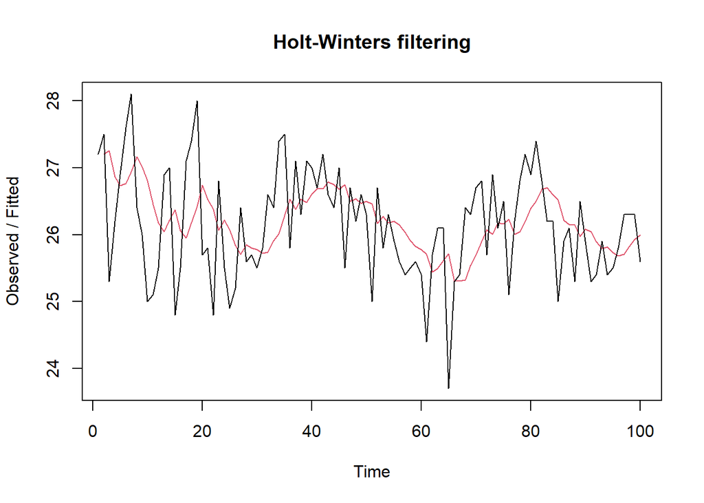

```r
#Cara 2 (fungsi Holtwinter)
ses1<- HoltWinters(train.ts, gamma = FALSE, beta = FALSE, alpha = 0.2)
plot(ses1)
```

```r
#ramalan
ramalan1<- forecast(ses1, h=25)
ramalan1
```

```
##     Point Forecast    Lo 80    Hi 80    Lo 95    Hi 95
## 101       25.91807 24.88924 26.94691 24.34460 27.49154
## 102       25.91807 24.86886 26.96728 24.31344 27.52270
## 103       25.91807 24.84887 26.98727 24.28287 27.55327
## 104       25.91807 24.82925 27.00689 24.25287 27.58328
## 105       25.91807 24.80998 27.02616 24.22339 27.61275
## 106       25.91807 24.79104 27.04511 24.19442 27.64172
## 107       25.91807 24.77241 27.06374 24.16593 27.67021
## 108       25.91807 24.75408 27.08207 24.13789 27.69825
## 109       25.91807 24.73603 27.10012 24.11029 27.72585
## 110       25.91807 24.71825 27.11789 24.08311 27.75304
## 111       25.91807 24.70074 27.13541 24.05632 27.77983
## 112       25.91807 24.68347 27.15268 24.02991 27.80624
## 113       25.91807 24.66644 27.16971 24.00386 27.83228
## 114       25.91807 24.64964 27.18651 23.97817 27.85798
## 115       25.91807 24.63306 27.20309 23.95281 27.88333
## 116       25.91807 24.61669 27.21946 23.92777 27.90837
## 117       25.91807 24.60052 27.23563 23.90305 27.93310
## 118       25.91807 24.58455 27.25160 23.87862 27.95752
## 119       25.91807 24.56877 27.26738 23.85449 27.98166
## 120       25.91807 24.55317 27.28298 23.83063 28.00552
## 121       25.91807 24.53774 27.29840 23.80704 28.02910
## 122       25.91807 24.52249 27.31365 23.78371 28.05243
## 123       25.91807 24.50740 27.32874 23.76064 28.07550
## 124       25.91807 24.49247 27.34367 23.73781 28.09834
## 125       25.91807 24.47770 27.35844 23.71521 28.12093
```

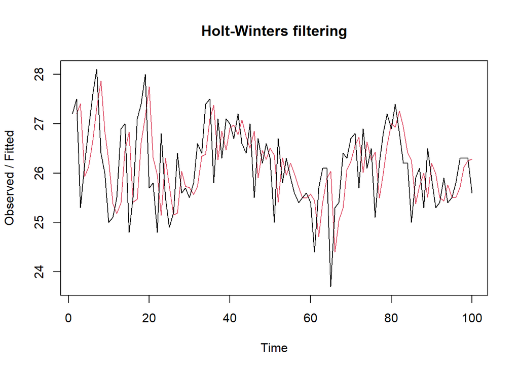

```r
ses2<- HoltWinters(train.ts, gamma = FALSE, beta = FALSE, alpha = 0.7)
plot(ses2)
```

```r
#ramalan
ramalan2<- forecast(ses2, h=25)
ramalan2
```

```
##     Point Forecast    Lo 80    Hi 80    Lo 95    Hi 95
## 101       25.80523 24.72464 26.88582 24.15261 27.45785
## 102       25.80523 24.48620 27.12425 23.78795 27.82250
## 103       25.80523 24.28470 27.32575 23.47979 28.13067
## 104       25.80523 24.10695 27.50351 23.20793 28.40252
## 105       25.80523 23.94611 27.66434 22.96195 28.64850
## 106       25.80523 23.79812 27.81233 22.73562 28.87483
## 107       25.80523 23.66032 27.95013 22.52487 29.08558
## 108       25.80523 23.53085 28.07960 22.32687 29.28359
## 109       25.80523 23.40836 28.20209 22.13954 29.47091
## 110       25.80523 23.29184 28.31861 21.96133 29.64912
## 111       25.80523 23.18048 28.42997 21.79103 29.81942
## 112       25.80523 23.07367 28.53679 21.62766 29.98279
## 113       25.80523 22.97087 28.63959 21.47045 30.14000
## 114       25.80523 22.87167 28.73878 21.31874 30.29171
## 115       25.80523 22.77572 28.83473 21.17200 30.43846
## 116       25.80523 22.68272 28.92774 21.02976 30.58069
## 117       25.80523 22.59240 29.01805 20.89164 30.71881
## 118       25.80523 22.50456 29.10589 20.75730 30.85316
## 119       25.80523 22.41900 29.19146 20.62644 30.98402
## 120       25.80523 22.33554 29.27491 20.49880 31.11165
## 121       25.80523 22.25405 29.35640 20.37417 31.23629
## 122       25.80523 22.17438 29.43607 20.25233 31.35812
## 123       25.80523 22.09643 29.51403 20.13311 31.47734
## 124       25.80523 22.02008 29.59037 20.01634 31.59411
## 125       25.80523 21.94524 29.66521 19.90188 31.70857
```

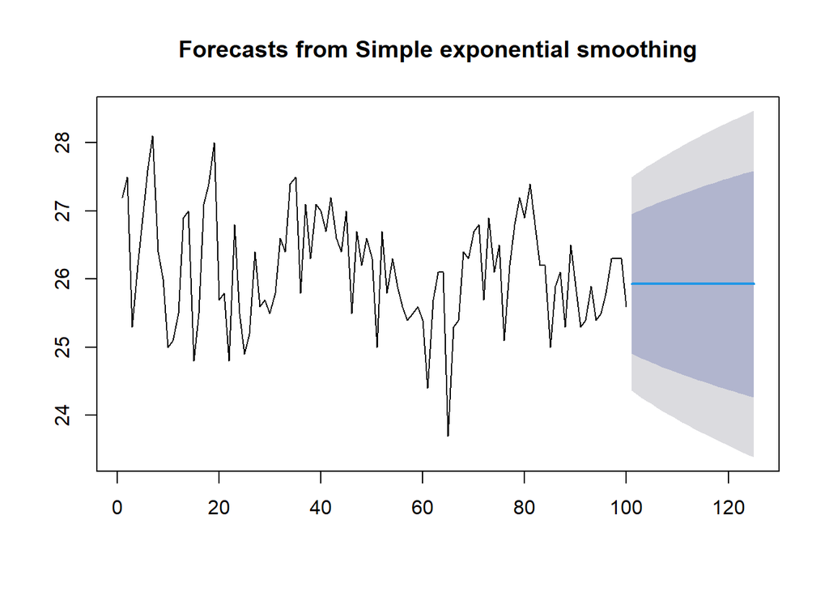

```r
#SES
ses.opt <- ses(train.ts, h = 25, alpha = NULL)
plot(ses.opt)
```

```r
ses.opt
```

```
##     Point Forecast    Lo 80    Hi 80    Lo 95    Hi 95
## 101       25.92903 24.90516 26.95290 24.36315 27.49490
## 102       25.92903 24.87084 26.98721 24.31067 27.54738
## 103       25.92903 24.83761 27.02045 24.25984 27.59821
## 104       25.92903 24.80535 27.05270 24.21052 27.64754
## 105       25.92903 24.77400 27.08406 24.16257 27.69549
## 106       25.92903 24.74348 27.11458 24.11588 27.74217
## 107       25.92903 24.71372 27.14434 24.07037 27.78768
## 108       25.92903 24.68467 27.17338 24.02595 27.83211
## 109       25.92903 24.65629 27.20177 23.98254 27.87552
## 110       25.92903 24.62852 27.22953 23.94008 27.91798
## 111       25.92903 24.60134 27.25672 23.89851 27.95955
## 112       25.92903 24.57470 27.28335 23.85777 28.00029
## 113       25.92903 24.54858 27.30948 23.81781 28.04025
## 114       25.92903 24.52294 27.33512 23.77860 28.07946
## 115       25.92903 24.49776 27.36030 23.74009 28.11797
## 116       25.92903 24.47301 27.38504 23.70225 28.15581
## 117       25.92903 24.44868 27.40937 23.66504 28.19302
## 118       25.92903 24.42475 27.43331 23.62843 28.22963
## 119       25.92903 24.40118 27.45687 23.59239 28.26567
## 120       25.92903 24.37798 27.48008 23.55690 28.30115
## 121       25.92903 24.35512 27.50294 23.52194 28.33612
## 122       25.92903 24.33258 27.52548 23.48747 28.37058
## 123       25.92903 24.31036 27.54770 23.45349 28.40457
## 124       25.92903 24.28844 27.56962 23.41996 28.43809
## 125       25.92903 24.26681 27.59125 23.38688 28.47118
```

```r
#Lamda Optimum Holt Winter
HWopt<- HoltWinters(train.ts, gamma = FALSE, beta = FALSE,alpha = NULL)
HWopt
```

```
## Holt-Winters exponential smoothing without trend and without seasonal component.
##
## Call:
## HoltWinters(x = train.ts, alpha = NULL, beta = FALSE, gamma = FALSE)
##
## Smoothing parameters:
##  alpha: 0.2824175
##  beta : FALSE
##  gamma: FALSE
##
## Coefficients:
##       [,1]
## a 25.93286
```

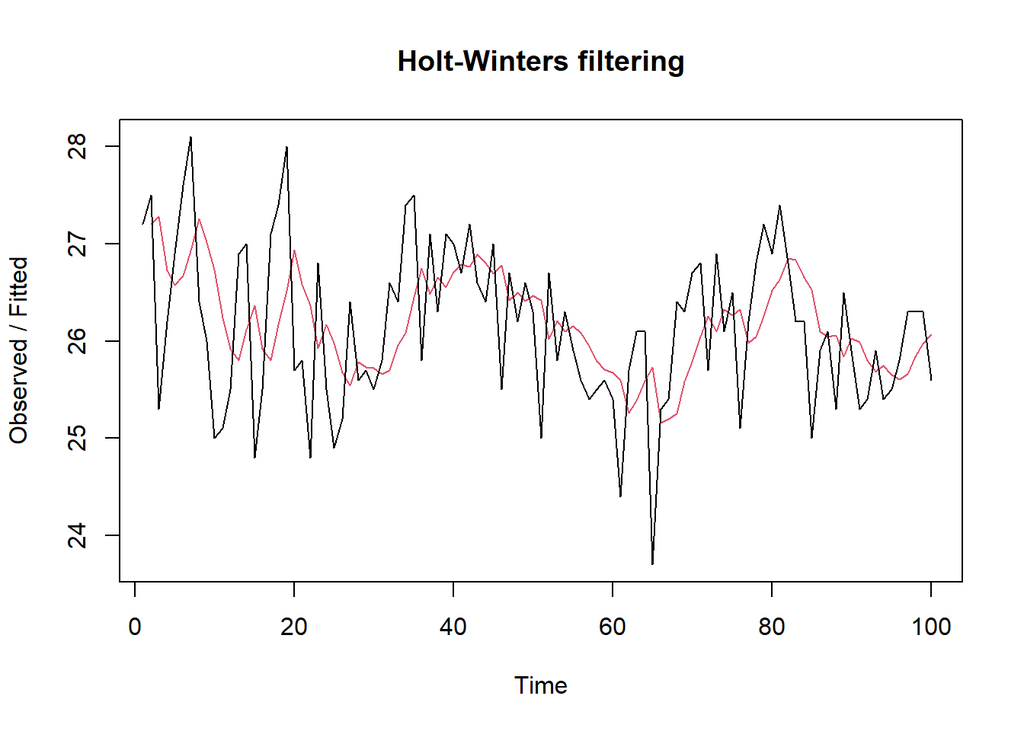

```r
plot(HWopt)
```

```r
#ramalan
ramalanopt<- forecast(HWopt, h=25)
ramalanopt
```

```
##     Point Forecast    Lo 80    Hi 80    Lo 95    Hi 95
## 101       25.93286 24.90754 26.95817 24.36478 27.50093
## 102       25.93286 24.86744 26.99827 24.30344 27.56227
## 103       25.93286 24.82879 27.03692 24.24433 27.62138
## 104       25.93286 24.79145 27.07426 24.18723 27.67849
## 105       25.93286 24.75529 27.11042 24.13193 27.73378
## 106       25.93286 24.72021 27.14550 24.07828 27.78743
## 107       25.93286 24.68612 27.17959 24.02614 27.83957
## 108       25.93286 24.65293 27.21278 23.97538 27.89033
## 109       25.93286 24.62059 27.24512 23.92591 27.93980
## 110       25.93286 24.58902 27.27669 23.87763 27.98808
## 111       25.93286 24.55818 27.30754 23.83046 28.03525
## 112       25.93286 24.52801 27.33770 23.78433 28.08138
## 113       25.93286 24.49848 27.36723 23.73916 28.12655
## 114       25.93286 24.46954 27.39617 23.69491 28.17080
## 115       25.93286 24.44117 27.42455 23.65151 28.21420
## 116       25.93286 24.41332 27.45239 23.60893 28.25678
## 117       25.93286 24.38598 27.47973 23.56711 28.29860
## 118       25.93286 24.35911 27.50660 23.52602 28.33970
## 119       25.93286 24.33269 27.53302 23.48561 28.38010
## 120       25.93286 24.30670 27.55901 23.44587 28.41985
## 121       25.93286 24.28112 27.58459 23.40675 28.45897
## 122       25.93286 24.25593 27.60978 23.36822 28.49749
## 123       25.93286 24.23111 27.63460 23.33027 28.53544
## 124       25.93286 24.20665 27.65906 23.29286 28.57285
## 125       25.93286 24.18254 27.68318 23.25597 28.60974
```

Setelah dilakukan peramalan, akan dilakukan perhitungan keakuratan hasil peramalan. Perhitungan akurasi ini dilakukan baik pada data latih dan data uji.

### Akurasi Data Latih

```r
#Keakuratan Metode
#Pada data training

# SES dengan alpha = 0.2
SSE1<-ses1$SSE
MSE1<-ses1$SSE/length(train.ts)
RMSE1<-sqrt(MSE1)

akurasi1 <- matrix(c(SSE1,MSE1,RMSE1))
row.names(akurasi1)<- c("SSE", "MSE", "RMSE")
colnames(akurasi1) <- c("Akurasi lamda=0.2")
akurasi1
```

```
##      Akurasi lamda=0.2
## SSE         63.5756464
## MSE          0.6357565
## RMSE         0.7973434
```

```r
# SES dengan alpha = 0.7
SSE2<-ses2$SSE
MSE2<-ses2$SSE/length(train.ts)
RMSE2<-sqrt(MSE2)

akurasi2 <- matrix(c(SSE2,MSE2,RMSE2))
row.names(akurasi2)<- c("SSE", "MSE", "RMSE")
colnames(akurasi2) <- c("Akurasi lamda=0.7")
akurasi2
```

```
##      Akurasi lamda=0.7
## SSE         69.7148002
## MSE          0.6971480
## RMSE         0.8349539
```

### Akurasi Data Uji

```r
# jumlah observasi uji
n_test <- nrow(testing)

# error (ramalan - aktual), samakan panjang dan tipe numeric
e1   <- as.numeric(ramalan1$mean)[1:n_test] - as.numeric(testing$TAVG)
e2   <- as.numeric(ramalan2$mean)[1:n_test] - as.numeric(testing$TAVG)
eopt <- as.numeric(ramalanopt$mean)[1:n_test] - as.numeric(testing$TAVG)

# SSE / MSE / RMSE untuk masing-masing model (abaikan NA)
SSEtesting1  <- sum(e1^2,  na.rm = TRUE)
MSEtesting1  <- mean(e1^2, na.rm = TRUE)
RMSEtesting1 <- sqrt(MSEtesting1)

SSEtesting2  <- sum(e2^2,  na.rm = TRUE)
MSEtesting2  <- mean(e2^2, na.rm = TRUE)
RMSEtesting2 <- sqrt(MSEtesting2)

SSEtestingopt  <- sum(eopt^2,  na.rm = TRUE)
MSEtestingopt  <- mean(eopt^2, na.rm = TRUE)
RMSEtestingopt <- sqrt(MSEtestingopt)

# Tabel ringkas
akurasitesting_SSE <- matrix(c(SSEtesting1, SSEtesting2, SSEtestingopt),
                             nrow = 3,
                             dimnames = list(c("SSE1","SSE2","SSEopt"), "Nilai"))
akurasitesting_SSE
```

```
##           Nilai
## SSE1   14.20709
## SSE2   16.11615
## SSEopt 14.00415
```

```r
akurasitesting_MSE <- matrix(c(MSEtesting1, MSEtesting2, MSEtestingopt),
                             nrow = 3,
                             dimnames = list(c("MSE1","MSE2","MSEopt"), "Nilai"))
akurasitesting_MSE
```

```
##            Nilai
## MSE1   0.5682834
## MSE2   0.6446459
## MSEopt 0.5601661
```

```r
akurasitesting_RMSE <- matrix(c(RMSEtesting1, RMSEtesting2, RMSEtestingopt),
                              nrow = 3,
                              dimnames = list(c("RMSE1","RMSE2","RMSEopt"), "Nilai"))
akurasitesting_RMSE
```

```
##             Nilai
## RMSE1   0.7538458
## RMSE2   0.8028984
## RMSEopt 0.7484424
```

## *Double Exponential Smoothing* (DES)

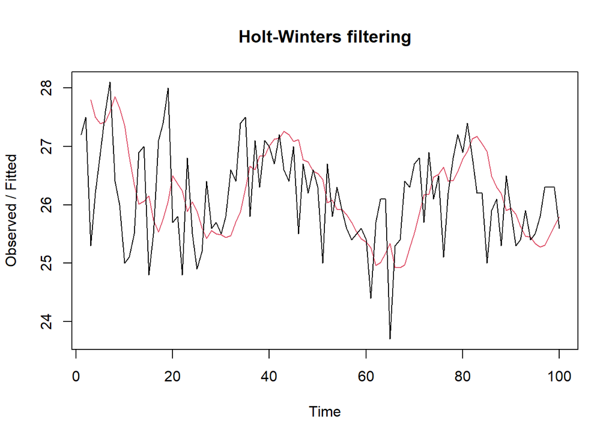

```r
#Lamda=0.2 dan gamma=0.2
des.1<- HoltWinters(train.ts, gamma = FALSE, beta = 0.2, alpha = 0.2)
plot(des.1)
```

```r
#ramalan
ramalandes1<- forecast(des.1, h=25)
ramalandes1
```

```
##     Point Forecast    Lo 80    Hi 80    Lo 95    Hi 95
## 101       25.77119 24.60075 26.94163 23.98116 27.56122
## 102       25.78851 24.58483 26.99218 23.94764 27.62937
## 103       25.80582 24.55833 27.05332 23.89795 27.71370
## 104       25.82314 24.52064 27.12565 23.83113 27.81515
## 105       25.84046 24.47149 27.20942 23.74681 27.93411
## 106       25.85777 24.41097 27.30458 23.64507 28.07047
## 107       25.87509 24.33936 27.41082 23.52639 28.22379
## 108       25.89241 24.25714 27.52767 23.39148 28.39333
## 109       25.90972 24.16487 27.65458 23.24119 28.57825
## 110       25.92704 24.06314 27.79094 23.07645 28.77764
## 111       25.94436 23.95255 27.93617 22.89814 28.99057
## 112       25.96167 23.83366 28.08969 22.70716 29.21619
## 113       25.97899 23.70701 28.25097 22.50430 29.45368
## 114       25.99631 23.57307 28.41954 22.29029 29.70232
## 115       26.01362 23.43228 28.59497 22.06580 29.96145
## 116       26.03094 23.28502 28.77686 21.83142 30.23047
## 117       26.04826 23.13163 28.96488 21.58766 30.50885
## 118       26.06557 22.97242 29.15872 21.33501 30.79614
## 119       26.08289 22.80767 29.35811 21.07387 31.09191
## 120       26.10021 22.63761 29.56281 20.80461 31.39580
## 121       26.11752 22.46245 29.77259 20.52758 31.70747
## 122       26.13484 22.28241 29.98728 20.24305 32.02663
## 123       26.15216 22.09764 30.20668 19.95130 32.35301
## 124       26.16947 21.90830 30.43065 19.65258 32.68637
## 125       26.18679 21.71455 30.65903 19.34709 33.02650
```

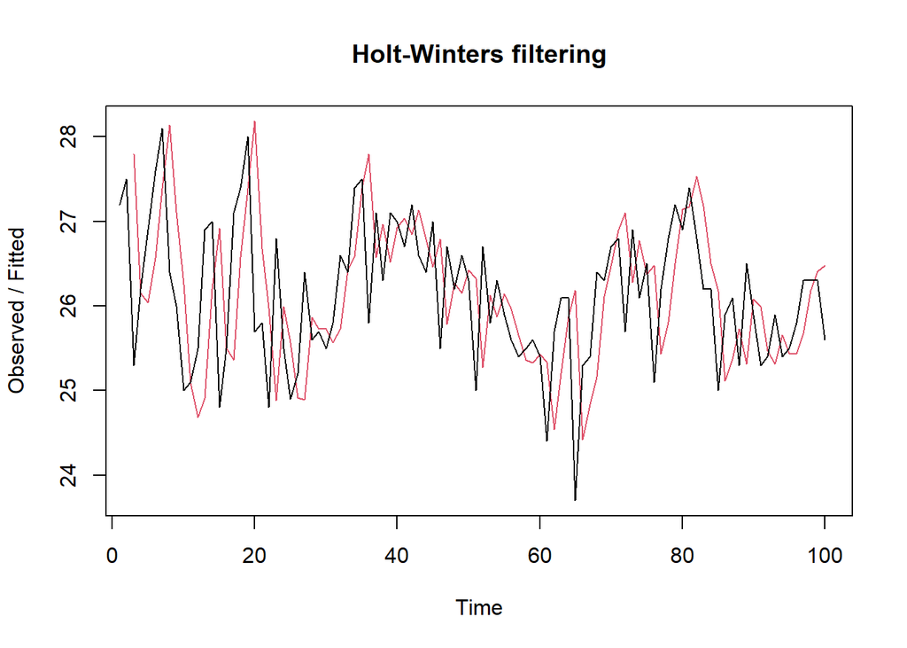

```r
#Lamda=0.6 dan gamma=0.3
des.2<- HoltWinters(train.ts, gamma = FALSE, beta = 0.3, alpha = 0.6)
plot(des.2)
```

```r
#ramalan
ramalandes2<- forecast(des.2, h=25)
ramalandes2
```

```
##     Point Forecast     Lo 80    Hi 80      Lo 95    Hi 95
## 101       25.92781 24.728653 27.12697 24.0938564 27.76177
## 102       25.90466 24.383853 27.42547 23.5787860 28.23053
## 103       25.88151 23.974126 27.78889 22.9644194 28.79859
## 104       25.85835 23.511673 28.20503 22.2694161 29.44729
## 105       25.83520 23.004572 28.66583 21.5061289 30.16427
## 106       25.81205 22.458255 29.16584 20.6828652 30.94123
## 107       25.78889 21.876542 29.70124 19.8054697 31.77231
## 108       25.76574 21.262259 30.26922 18.8782607 32.65322
## 109       25.74258 20.617583 30.86759 17.9045710 33.58060
## 110       25.71943 19.944260 31.49460 16.8870689 34.55179
## 111       25.69628 19.243729 32.14883 15.8279552 35.56460
## 112       25.67312 18.517204 32.82904 14.7290891 36.61716
## 113       25.64997 17.765735 33.53421 13.5920722 37.70787
## 114       25.62682 16.990236 34.26340 12.4183058 38.83533
## 115       25.60366 16.191520 35.01581 11.2090319 39.99830
## 116       25.58051 15.370314 35.79071  9.9653632 41.19566
## 117       25.55736 14.527277 36.58744  8.6883052 42.42641
## 118       25.53420 13.663006 37.40540  7.3787738 43.68963
## 119       25.51105 12.778051 38.24405  6.0376083 44.98449
## 120       25.48790 11.872917 39.10288  4.6655822 46.31021
## 121       25.46474 10.948073 39.98141  3.2634121 47.66607
## 122       25.44159 10.003954 40.87922  1.8317643 49.05141
## 123       25.41844  9.040968 41.79590  0.3712609 50.46561
## 124       25.39528  8.059496 42.73107 -1.1175151 51.90808
## 125       25.37213  7.059895 43.68436 -2.6340162 53.37827
```

Selanjutnya jika ingin membandingkan plot data latih dan data uji adalah sebagai berikut.

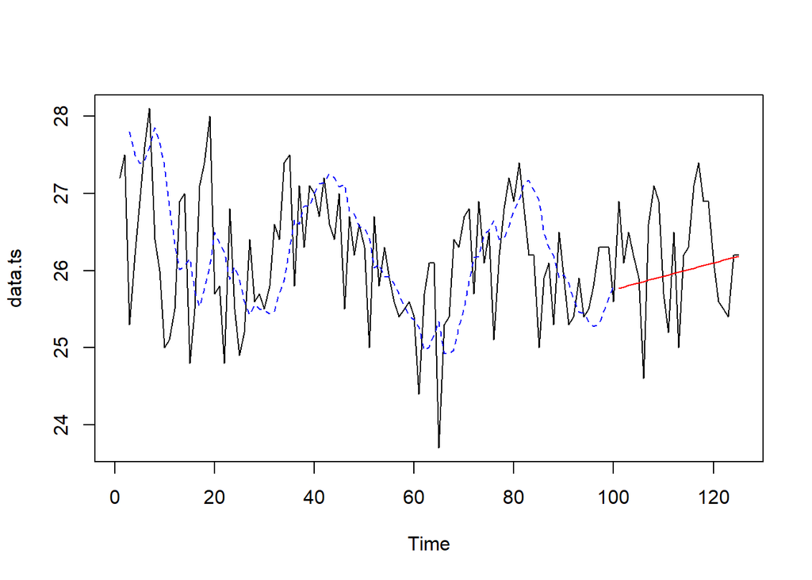

```r
plot(data.ts)
lines(des.1$fitted[,1], lty=2, col="blue")
lines(ramalandes1$mean, col="red")
```

Untuk mendapatkan nilai parameter optimum dari DES, argumen `alpha` dan `beta` dapat dibuat `NULL` seperti berikut.

```r
#Lamda dan gamma optimum
des.opt<- HoltWinters(train.ts, gamma = FALSE)
des.opt
```

```
## Holt-Winters exponential smoothing with trend and without seasonal component.
##
## Call:
## HoltWinters(x = train.ts, gamma = FALSE)
##
## Smoothing parameters:
##  alpha: 0.4579785
##  beta : 0.06734181
##  gamma: FALSE
##
## Coefficients:
##           [,1]
## a 25.929934311
## b -0.002669384
```

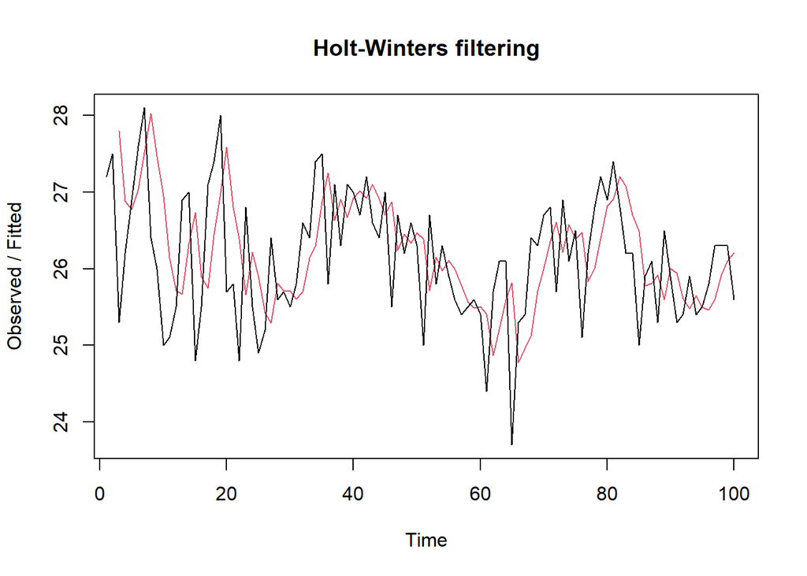

```r
plot(des.opt)
```

```r
#ramalan
ramalandesopt<- forecast(des.opt, h=25)
ramalandesopt
```

```
##     Point Forecast    Lo 80    Hi 80    Lo 95    Hi 95
## 101       25.92726 24.83016 27.02437 24.24938 27.60515
## 102       25.92460 24.70343 27.14576 24.05698 27.79221
## 103       25.92193 24.57423 27.26963 23.86080 27.98306
## 104       25.91926 24.44241 27.39610 23.66062 28.17789
## 105       25.91659 24.30791 27.52527 23.45632 28.37685
## 106       25.91392 24.17066 27.65717 23.24784 28.58000
## 107       25.91125 24.03066 27.79184 23.03513 28.78737
## 108       25.90858 23.88789 27.92927 22.81820 28.99896
## 109       25.90591 23.74236 28.06946 22.59705 29.21477
## 110       25.90324 23.59409 28.21239 22.37171 29.43478
## 111       25.90057 23.44311 28.35803 22.14221 29.65894
## 112       25.89790 23.28943 28.50638 21.90858 29.88722
## 113       25.89523 23.13308 28.65738 21.67089 30.11958
## 114       25.89256 22.97410 28.81103 21.42915 30.35597
## 115       25.88989 22.81250 28.96728 21.18343 30.59636
## 116       25.88722 22.64833 29.12612 20.93377 30.84068
## 117       25.88455 22.48161 29.28750 20.68021 31.08890
## 118       25.88189 22.31238 29.45139 20.42280 31.34097
## 119       25.87922 22.14066 29.61777 20.16159 31.59684
## 120       25.87655 21.96648 29.78661 19.89662 31.85647
## 121       25.87388 21.78988 29.95788 19.62794 32.11982
## 122       25.87121 21.61087 30.13154 19.35559 32.38683
## 123       25.86854 21.42950 30.30758 19.07961 32.65746
## 124       25.86587 21.24578 30.48596 18.80005 32.93168
## 125       25.86320 21.05975 30.66665 18.51695 33.20945
```

Selanjutnya akan dilakukan perhitungan akurasi pada data latih maupun data uji dengan ukuran akurasi SSE, MSE dan MAPE.

### Akurasi Data Latih

```r
#Akurasi Data Training
ssedes.train1<-des.1$SSE
msedes.train1<-ssedes.train1/length(train.ts)
sisaandes1<-ramalandes1$residuals
head(sisaandes1)
```

```
## Time Series:
## Start = 1
## End = 6
## Frequency = 1
## [1]       NA       NA -2.50000 -1.30000 -0.48800  0.18112
```

```r
mapedes.train1 <- sum(abs(sisaandes1[3:length(train.ts)]/train.ts[3:length(train.ts)])
                      *100)/length(train.ts)

akurasides.1 <- matrix(c(ssedes.train1,msedes.train1,mapedes.train1))
row.names(akurasides.1)<- c("SSE", "MSE", "MAPE")
colnames(akurasides.1) <- c("Akurasi lamda=0.2 dan gamma=0.2")
akurasides.1
```

```
##      Akurasi lamda=0.2 dan gamma=0.2
## SSE                       81.4187375
## MSE                        0.8141874
## MAPE                       2.7032859
```

```r
ssedes.train2<-des.2$SSE
msedes.train2<-ssedes.train2/length(train.ts)
sisaandes2<-ramalandes2$residuals
head(sisaandes2)
```

```
## Time Series:
## Start = 1
## End = 6
## Frequency = 1
## [1]       NA       NA -2.50000  0.05000  0.86100  1.03042
```

```r
mapedes.train2 <- sum(abs(sisaandes2[3:length(train.ts)]/train.ts[3:length(train.ts)])
                      *100)/length(train.ts)

akurasides.2 <- matrix(c(ssedes.train2,msedes.train2,mapedes.train2))
row.names(akurasides.2)<- c("SSE", "MSE", "MAPE")
colnames(akurasides.2) <- c("Akurasi lamda=0.6 dan gamma=0.3")
akurasides.2
```

```
##      Akurasi lamda=0.6 dan gamma=0.3
## SSE                       84.9614307
## MSE                        0.8496143
## MAPE                       2.6997474
```

### Akurasi Data Uji

```r
#Akurasi Data Testing
selisihdes1<-ramalandes1$mean-testing$TAVG
selisihdes1
```

```
## Time Series:
## Start = 101
## End = 125
## Frequency = 1
##  [1] -1.1288100699 -0.3114933647 -0.6941766595 -0.3768599542 -0.0595432490
##  [6]  1.2577734562 -0.7249098386 -1.2075931334 -0.9902764282  0.2270402770
## [11]  0.7443569822 -0.5383263126  0.9789903926 -0.2036929022 -0.2863761969
## [16] -1.0690594917 -1.3517427865 -0.8344260813 -0.8171093761  0.0002073291
## [21]  0.5175240343  0.6348407395  0.7521574447 -0.0305258501 -0.0132091449
```

```r
SSEtestingdes1<-sum(selisihdes1^2)
MSEtestingdes1<-SSEtestingdes1/length(testing$TAVG)
MAPEtestingdes1<-sum(abs(selisihdes1/testing$TAVG)*100)/length(testing$TAVG)

selisihdes2<-ramalandes2$mean-testing$TAVG
selisihdes2
```

```
## Time Series:
## Start = 101
## End = 125
## Frequency = 1
##  [1] -0.97218697 -0.19534049 -0.61849400 -0.34164751 -0.06480103  1.21204546
##  [7] -0.81110805 -1.33426157 -1.15741508  0.01943141  0.49627789 -0.82687562
## [13]  0.64997087 -0.57318264 -0.69633616 -1.51948967 -1.84264318 -1.36579670
## [19] -1.38895021 -0.61210372 -0.13525724 -0.05841075  0.01843574 -0.80471778
## [25] -0.82787129
```

```r
SSEtestingdes2<-sum(selisihdes2^2)
MSEtestingdes2<-SSEtestingdes2/length(testing$TAVG)
MAPEtestingdes2<-sum(abs(selisihdes2/testing$TAVG)*100)/length(testing$TAVG)

selisihdesopt<-ramalandesopt$mean-testing$TAVG
selisihdesopt
```

```
## Time Series:
## Start = 101
## End = 125
## Frequency = 1
##  [1] -0.97273507 -0.17540446 -0.57807384 -0.28074323  0.01658739  1.31391800
##  [7] -0.68875138 -1.19142076 -0.99409015  0.20324047  0.70057108 -0.60209830
## [13]  0.89523231 -0.30743707 -0.41010646 -1.21277584 -1.51544522 -1.01811461
## [19] -1.02078399 -0.22345338  0.27387724  0.37120785  0.46853847 -0.33413092
## [25] -0.33680030
```

```r
SSEtestingdesopt<-sum(selisihdesopt^2)
MSEtestingdesopt<-SSEtestingdesopt/length(testing$TAVG)
MAPEtestingdesopt<-sum(abs(selisihdesopt/testing$TAVG)*100)/length(testing$TAVG)

akurasitestingdes <-
  matrix(c(SSEtestingdes1,MSEtestingdes1,MAPEtestingdes1,SSEtestingdes2,MSEtestingdes2,
           MAPEtestingdes2,SSEtestingdesopt,MSEtestingdesopt,MAPEtestingdesopt),
         nrow=3,ncol=3)
row.names(akurasitestingdes)<- c("SSE", "MSE", "MAPE")
colnames(akurasitestingdes) <- c("des ske1","des ske2","des opt")
akurasitestingdes
```

```
##       des ske1   des ske2    des opt
## SSE  14.094174 20.1282785 14.5107722
## MSE   0.563767  0.8051311  0.5804309
## MAPE  2.398478  2.8013082  2.4462716
```

# Perbandingan SMA, DMA, ESE, DES

```r
akurasi_final <-
  matrix(c(SSE_test.sma, MSE_test.sma,
           SSE_test.dma, MSE_test.dma,
           SSEtesting1, MSEtesting1,
           SSEtesting2, MSEtesting2,
           SSEtestingopt, MSEtestingopt,
           SSEtestingdes1, MSEtestingdes1,
           SSEtestingdes2, MSEtestingdes2,
           SSEtestingdesopt, MSEtestingdesopt),nrow=8,ncol=2)
row.names(akurasi_final)<- c("SMA", "DMA", "SES 0,2", "SES 0,7", "SES OPT", "DES 0,2", "DES 0,6", "DES OPT")
colnames(akurasi_final) <- c("SSE","MSE")
akurasi_final
```

[output not shown]